# Conexiones a internet móvil en Chile durante pandemia

Por:Sebastián Celaya

05-12-2021

# Resumen

Las conexiones a internet móvil es un medio de de comunicación digital que conecta dispositivos electrónicos con la red de internet. En este informe analizaremos el impacto que tuvo la pandemia sobre las empresas de conexiones a internet de Chile. Los datos utilizados provienen de la Subsecretaría de Telecomunicacipones de Chile, esta contienen información acerca del número de personas que estan recibiendo el servicio, que tipo de internet es el que reciben y que compañía es de la que reciben este servicio. Los resultados mostrarán las preferencias de las personas, sobre la empresa y la calidad de internet que estos reciben. Lograremos distinguir cual es la empresa que predomina en el mercado.

# Antecedentes

La velocidad de internet móvil se mide segun la cantidad de información recibida en un segundo. La información se mide en bytes(B) y existen una métrica para valores muy altos de bytes, la cual es la siguiente:

| Metrica | Bytes |
| --- | --- |
| Kilobyte(Kb) | 1.024 |
| Megabyte(Mb) | 1.048.576 |
| Gigabyte(Gb) | 1.073.741.824 |
| Terabyte(Tb) | 1.099.511.627.776 |

Y existen otros pero para este informe no serán de relevancia. La abreviación de los datos recibidos en un segundo, son las mismas de las métricas con el sufijo *ps*.

# Introducción

En la sociedad actual el internet se ha vuelto algo fundamental en nuestras vidas. Muchas empresas han surgido de esta necesidad. En Chile hay 3 empresas que se destacan sobre las demás: Movistar, Entel y Claro. Actualmente estas empresas cuentan con 3 tipos de internet móvil:

| Tipo | caracteristica |
| --- | --- |
| 2G | velocidad de 384 Kbps |
| 3G | velocidad de 21Mbps |
| 4G | velocidad de 326,4Mbps |

Debido a la velocidad que tiene cada tipo, estos tienen ciertas características en su uso. Las conexiones 2G fue la primera red digital que disponía de SMS con mensajes cortos de 160 caracteres. Las conexiones 3G introdujo la tecnología MIMO, que emite señales inalámbricas simultaneamente (puede usar más datos al mimo tiempo). Las conexiones 4G logró establecer videollamadas, e ir más allá de los SMS con la aplicación WhatsApp

Esta información observada es de relevancia, puesto que se podrá apreciar un buen manejo de ciertas empresas haciendo un juicio personal de esta información. Para observar lo antes mencionado usaremos los datos de las empresas en epocas de pandemia, donde el internet móvil tiene una intensa demanda en comparación a otros años (lo veremos en un gráfico).

# Datos

En este informe se analizarán los datos de las empresas de conexión a internet móvil que tiene la Subsecretaría de Telecomunicaciones de Chile. Los datos que tenemos son cifras que indican el número de personas que están recibiendo el servicio de ciertas empresas según el año y mes.

Dentro del excel que entrega la Subsecretaría, por motivos de manejos de datos, a la columna de los años se agregaron el año a cada fila. En el excel descargable de la Subsecretaría tiene celdas concatenadas que dificultan el manejo de datos. Por estas razones el excel fue modificado.

Las variables que encontraremos son:

| Variables | Significado |
| --- | --- |
| Fecha | Categoría que incluye las variables de la Fecha |
| Año | Variable del año de los datos |
| Mes | Variable del mes de los datos |
| Conexiones con tecnología 2G | Categoría de todas las empresas que ofrecen servicio 2G |
| Conexiones con tecnología 3G | Categoría de todas las empresas que ofrecen servicio 3G |
| Conexiones con tecnología 4G | Categoría de todas las empresas que ofrecen servicio 4G |
| Movistar | Conexiones de la empresa Movistar |
| Entel PCS | Conexiones de la empresa Entel PCS |
| Claro | Conexiones de la empresa Claro |
| Total de conexiones 2G | Total de conexiones de todas las empresas que ofrecen servicio 2G |
| Total de conexiones 3G | Total de conexiones de todas las empresas que ofrecen servicio 3G |
| Total de conexiones 4G | Total de conexiones de todas las empresas que ofrecen servicio 4G |
| Total de Conexiones móviles | Total de conexiones de todas las empresas, sin importar el servicio ofrecido |

Existen otras variables de empresas, pero no son tan influyentes como Movistar , Entel PCS y Claro.

# Resultados

## Analisis Total de Conexiones

Vamos a hacer una comparacion general de lo que pasó en los años 2019 y 2020 con el total de conexiones a internet móvil.

### Conexiones del 2019

Primero emprezemos analizando las conexiones del 2019:

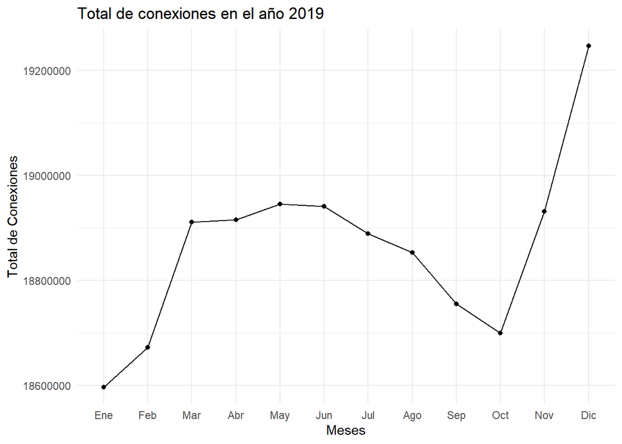

Podemos apreciar que en tiempos antes de la pandemia entre Enero y Octubre, la demanda era variante. Luego desde Octubre, hasta Diciempre, la demanda sube considerablemente. De esta forma hay irregularidades en la demanda en el año 2019.

### Conexiones del 2020

Ahora vamos a observar que pasa en el año 2020 (época de pandemia):

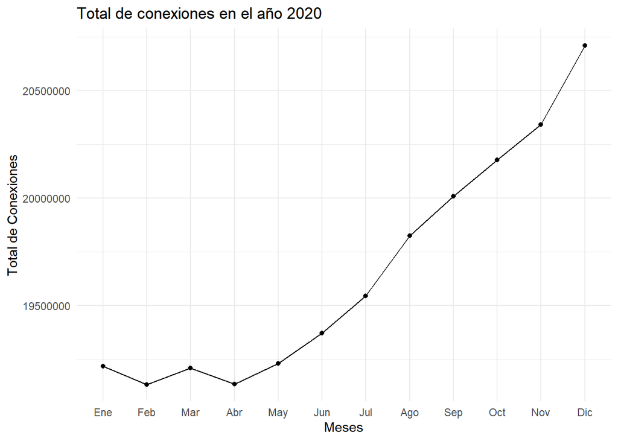

En este gráfico hay una notoria alza en la demanda de internet móvil a partir de Abril. Hay muchas razones por las cuales se presente esta alza, entre ellas están:

- La cuarentena a partir de Marzo.
- La entrada a clases online.
- Las universidades compran bolsas de internet a los estudiantes que necesiten.
- Comienzo de jornadas de trabajo desde la casa.

Todas estas causas generan una gran necesidad, tener internet en todo momento. A pesar de existir el internet fijo, es el internet móvil el que sube su demanda. Esto se explica debido a la cuarentena del pais, donde el servicio tecnico no puede ser presencialmente.

ya teniendo esto en cuenta, veamos los números de las 3 grandes empresas de Chile:

## Analisis servicio 2G

[figure not shown]

En el caso del servicio de internet 2G vemos que Entel y Movistar sufren una caida en el número de conexiones ofrecidas. Por lo tanto para aquellos usuarios que quieran ocupar este servicio de dichas empresas, estas han tenido bajas en sus números. Mientras que la empresa Claro se mantiene sus números constantes.

Hay muchas interpretaciones para estos números, algunas de ellas son:

- Mala gestión por parte de la empresa para ofrecer el servicio 2G.
- Cambio a un servicio de mayor calidad (3G o 4G).
- Preferencia de los usuarios de aplicaciones de mensajerias (WhatsApp o Telegram) sobre los SMS.

Estos factores pueden explicar las conexiones de estas 3 empresas.

## Analisis servicio 3G

[figure not shown]

Estas 3 empresas tuvieron una caida en el número de conexiones del servicio 3G. Teniendo 2 posibles explicaciones de este fenómeno:

- Las empresas no impartieron este servicio de la mejor manera.
- Los usuarios prefieren una mejor calidad de internet, que puede ofrecer el 4G.

El primero requiere de infromación sobre quejas de este servicio, las cuales no estan abiertas para el publico. Mientras que la segunda explicación lo vamos a ver si las empresas en su servicio 4G se ve un alza de la cantidad de usuarios.

Por el momento tomatemos la segunda idea como una teoría posible que explique lo sucedido en el gráfico.

## Análisis servicio 4G

[figure not shown]

En este gráfico observamos una enorme alza de las cantidad de conexiones en Movistar y Entel. Por lo tanto la teoría plantea anteriormente, puede tener mayor respaldo para estas 2 empresas.

Por otro lado Claro tiene una decaida en sus número de conexiones, por lo tanto la teoría anterior no aplica. Podríamos explicar la caida de los números de Claro por una mala ejecucion de la empresa en su servicio.

Hay que mencionar que además de estas teorías, pueden existir más. Nosotros fijamos estas 2 porque son simples y no necesitan de mucho contexto para entenderse.

## Análisis según la empresa

Hemos visto los datos de las empresas según el servicio que estas ofrezcan. Pero ahora es momento de observar de manera global los datos de las empresas para llegar a una conclusión respaldada con datos.

[figure not shown]

En este gráfico podemos observar la evolución de las 3 empresas, junto con lo visto en los demás gráficos podemos dar los resultados acerca de este tema.

# Conclusión

Finalmente, podemos decir que el numero de conexiones de Entel y Movistar van a seguir subiendo. Por su parte Claro mientras no hagan algo con la baja de sus números, estos van a seguir bajando.

# Referencias

R Core Team (2021). R: A language and environment for statistical computing. R Foundation for Statistical Computing, Vienna, Austria. URL https://www.R-project.org/.

Hadley Wickham (2021). tidyr: Tidy Messy Data. R package version 1.1.3. https://CRAN.R-project.org/package=tidyr

Hadley Wickham and Jim Hester (2021). readr: Read Rectangular Text Data. R package version 2.0.1. https://CRAN.R-project.org/package=readr

H. Wickham. ggplot2: Elegant Graphics for Data Analysis. Springer-Verlag New York, 2016.

Hadley Wickham, Romain François, Lionel Henry and Kirill Müller (2021). dplyr: A Grammar of Data Manipulation. R package version 1.0.7. https://CRAN.R-project.org/package=dplyr

Hadley Wickham and Jennifer Bryan (2019). readxl: Read Excel Files. R package version 1.3.1. https://CRAN.R-project.org/package=readxl

Sam Firke (2021). janitor: Simple Tools for Examining and Cleaning Dirty Data. R package version 2.1.0. https://CRAN.R-project.org/package=janitor

Hadley Wickham (2019). stringr: Simple, Consistent Wrappers for Common String Operations. R package version 1.4.0. https://CRAN.R-project.org/package=stringr

Claus O. Wilke (2020). ggtext: Improved Text Rendering Support for ‘ggplot2’. R package version 0.1.1. https://CRAN.R-project.org/package=ggtext

Bob Rudis (2020). hrbrthemes: Additional Themes, Theme Components and Utilities for ‘ggplot2’. R package version 0.8.0. https://CRAN.R-project.org/package=hrbrthemes

Jeroen Ooms (2021). magick: Advanced Graphics and Image-Processing in R. R package version 2.7.3. https://CRAN.R-project.org/package=magick

Subsecretaria de Telecomunicaciones (SubTel). Estadísticas, internet. Series conexiones internet móvil. https://www.subtel.gob.cl/estudios-y-estadisticas/internet/